[figure not shown]

Introduction to general principles of impact evaluation

Dan Killian, MESP Evaluation Specialist

Contents:

- Introduction to potential outcomes theory
- Showcasing impact evaluation designs

# We want to know the causal effect of a project on its beneficiaries

Job training on earnings and employment

Class size on test scores

School leadership on teacher morale

Teacher qualifications on student outcomes

# Potential outcomes - i

Consider an indicator for a potential beneficiary, Di

D tells us whether there is a project, or a “treatment”

The subscript i denotes a single individual who is either treated or not treated

Di = 1 means participation in a project (beneficiary)

Di = 0 means no participation in a project

# Potential outcomes - ii

Consider an indicator for the outcome of a potential beneficiary, Yi

Y1i is the outcome after project participation

Y0i is the outcome without any project

Note that Y1 and Y0 denote *possibilities* for the *same person*, unit i !

# Potential outcomes - iii

The effect of the project (treatment effect) on person i is the difference between the two potential outcomes

Treatment effect = Y1i - Y0i

This is the difference in potential outcomes for the *same person*

A person participates in a project, and then goes back in time and does not participate in the project

# Potential outcomes - iv

But how can one person be both treated and untreated?

In the real world, person i experiences one of the potential outcomes, but not both

If Di = 1, the potential outcome of Yi becomes Y1i in fact and the potential outcome of Y0i is unobserved

If Di = 0, the potential outcome of Yi becomes Y0i in fact and the potential outcome of Y1i is unobserved

# The fundamental problem of causal inference - i

This is the fundamental problem of causal inference:

We observe only one outcome, but we need both outcomes to describe the effect of the project

We refer to the outcome that didn’t happen as the *counterfactual*, or what would have happened in the absence of the project

Researchers sometimes refer to impact evaluation as a “missing data problem”, because we are missing two pieces of information about what happens with or without the treatment

| Group | Y1i | Y0i |
| --- | --- | --- |
| Treatment | Observed | Counterfactual |
| Control | Counterfactual | Observed |

# The fundamental problem of causal inference - ii

How do we estimate the effect of a project, if we cannot observe the same person go through both potential outcomes?

We must compare a person who was treated with a person who was not treated

But, what are the differences between those two people? How do we know that project participation is the only difference between them?

# Randomization solves the selection problem

If we are able to randomize from the pool of eligible participants, we have a theoretical basis for comparing these two groups

Under randomization, Y1i = Y0i (theoretically!)

So all we have to do is take the difference in means as the treatment effect

# Comparing different groups

If you cannot randomize treatment and control groups, there are two common sources of differences between groups that you must worry about

The groups could be different at the start of the program (baseline bias)

The groups might be affected differently by the project (differential effect bias)

In development programs, it is difficult to randomize treatment and control groups

So the researcher must always think about how treated and untreated groups might be different

Most evaluation designs are motivated by the difficulty of not having randomization

# Comparing different groups - example

| Group | Baseline | Endline |
| --- | --- | --- |
| Treatment (D=1) | 6 | 10 |
| Comparison (D=0) | 5 | 8 |

- Baseline bias: 6 - 5 = 1
- Differential effects bias: (10-6) - (8-5) = 1

# Is there a way to investigate whether two groups are comparable?

Examine the group means on observable characteristics

If the means are standardized, differences above 0.1 are worrisome and above 0.2 are a danger

[figure not shown]

# Actual example for CITIES matched municipalities

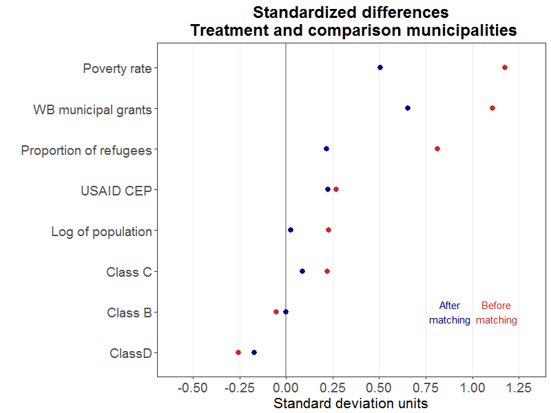

# Inferential design across municipalities

- For institional indicators and public pereptions at the population level, compare treatment municipalities with comparison municipalities over time

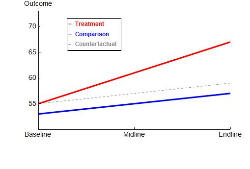

This design is called “difference-in-differences (d-i-d)”

- Why? What are the assumptions? What are the validity threats?

# Inferential design within municipalities

- For public perceptions at the activity level, compare direct beneficiaries with indirect beneficiaries within municipalities

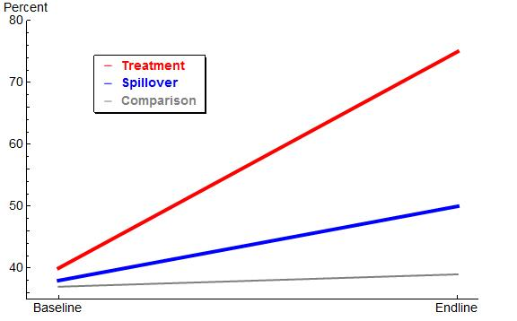

This design may be described as a d-i-d with spillover group

Under this design, indicators can be examined both across and within municipalities to learn about the effect of CITIES

- How? Under what conditions / assumptions?

# Interrupted time series design

If we have many measurements over time, then the comparison group could be the treatment group *before* treatment

- There must be enough pre-treatment measures to establish a clear trend

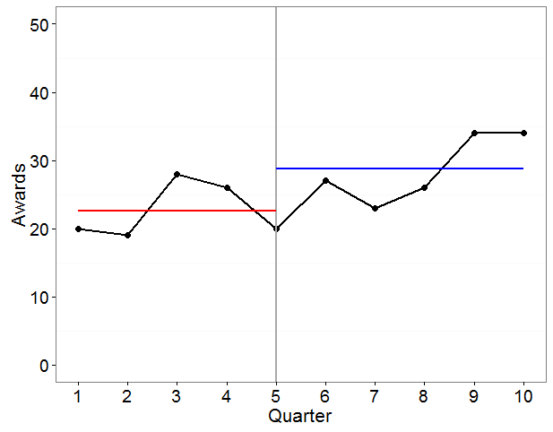

# Regression discontinuity design

If we assign treatment based on a “break”, we can estimate the treatment effect as the magnitude of the “jump” over the break

The discontinuity can be sharp (absolute cutoff score of 50 on a test)

The discontinuity can be “fuzzy” (distance from a waste treatment plant)

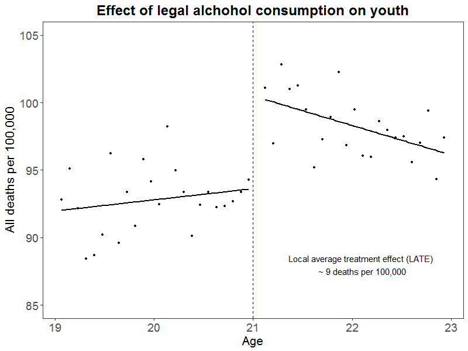

What is being estimated here? Is it believable?

# Regression discontinuity - ii

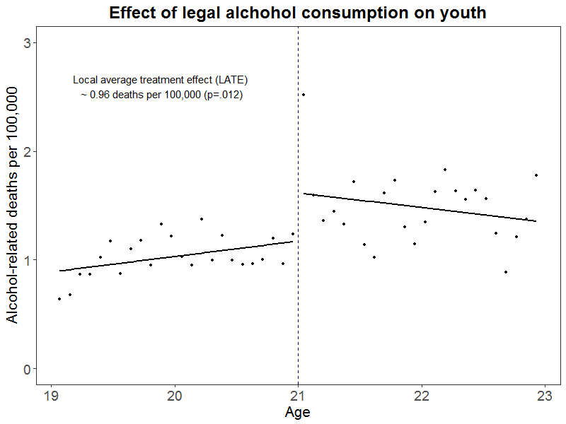

Thank you!

MESP Team